# H10 Stage 2: implementation, diagnostics, and V0 comparison

Age, measured biological sex, and personal light exposure — author result gate

Published

August 11, 2026

**NoteH10-G2 status**

The author approved H10-G2 and the later reader and provenance stages. This report incorporates both the sealed FIND-049/CHG-101 gap-MDER repair and METRIC-011, which normalized eight primary darkest-10-hour mean values from numerical noise to exact zero. METRIC-011 reopened only the affected L10 branches and their complete BH families; all other model objects and raw *p*-values remained frozen.

# 1 Question and answer from the audited implementation

The preregistered hypothesis is:

> “Personal light exposure metrics depend on age and gender.”

The preregistration’s wording is retained as a quotation. The audited inference uses the construct actually measured in the approved demographic input: **biological sex**, coded Male and Female. It does not substitute, derive, or infer gender.

**ImportantResult in brief**

For the primary near-eye placement, older age was associated with a higher brightest-10-hour mean, more time above 1,000 lx melEDI, and a higher melEDI dose after the four separate 17-metric BH corrections. Their per-decade ratios were 1.31 (95% CI 1.09–1.58), 1.27 (1.11–1.45), and 1.31 (1.09–1.56), respectively. No near-eye Female–Male contrast or site-interaction family member met its adjusted rule.

Complementary chest models showed positive age associations for mean melEDI, brightest-10-hour mean, time above 1,000 lx melEDI, waking time above 250 lx melEDI, longest continuous period above 250 lx melEDI, and melEDI dose. Female participants had lower mean melEDI and darkest-10-hour mean than Male participants. Chest age associations varied by site for the midpoint of the brightest 10 hours and last light timing above 250 lx melEDI. These are adjusted associations, not causal effects, and the placement models were never pooled.

The **gap-timing-unaware dataset** is the dataset applying the 50%-per-hour and 80%-per-day coverage rules but not using the remaining gaps’ time of day in metric-specific support decisions. It is contrasted once here with the primary dataset as time-sensitive; below, the latter is called simply the primary dataset.

# 2 Author decisions and frozen inputs

All 13 Stage 1 decisions, including the amended Gaussian/identity contract for pre-sleep TBT10, were recorded as approved before fitting.

Approved H10 Stage 1 decisions

| Decision | Disposition | Approved |
| --- | --- | --- |
| H10-G1 | Four separate 17-member BH families per placement | Yes |
| H10-G2 | Site-adjusted common associations are primary estimands | Yes |
| H10-G3 | Final shared response package; pre-sleep TBT10 amended to Gaussian identity before fitting | Yes |
| H10-G4 | Participant random intercept for participant-day outcomes | Yes |
| H10-G5 | Age per decade; measured biological sex Male then Female | Yes |
| H10-G6 | Near-eye primary and chest complementary without pooling | Yes |
| H10-G7 | Gap-timing-unaware and common-key sensitivities | Yes |
| H10-G8 | Declared metric and preregistered-exclusion sensitivities | Yes |
| H10-G9 | Explicit diagnostic acceptance classification | Yes |
| H10-G10 | Model-based 95% confidence intervals; no ungated bootstrap | Yes |
| H10-G11 | Non-selective site-specific interaction summaries | Yes |
| H10-G12 | Paired participant-level IS and IV unavailable | Yes |
| H10-G13 | Current shared pins after METRIC-010/FIND-049 and METRIC-011; remaining PREP-003/FIND-044 qualification is state-support-only | Yes |

H10-G3 includes the pre-fit amendment from Tweedie/log to Gaussian/identity for pre-sleep TBT10.

The runner independently repeated `verify_base_model_data_artifacts()` in R 4.6.1 before fitting. It reproduced the current base manifest, input-bundle hash, and 816 near-eye plus 902 chest participant-days. The independently audited METRIC-010 MDER manifest, the METRIC-011 decision and evidence manifest, the corrected gap-preparation release, and every other separately pinned input hash also matched.

Current prepared-input gate

[output not shown]

PREP-003/FIND-044 is a provenance qualification, not evidence that the prepared data are incorrect.

The complete SHA-256 audit is stored in `artifacts/06_model_data/H10/H10_input_audit.csv`. The decisive hashes were:

Pinned H10 input identities

| Input | Observed SHA-256 | Verified |
| --- | --- | --- |
| metric_manifest | 028bce108339c1277df4a070597430ea20b49c34c2888f4eef42741c1fe76a5e | PASS |
| site_context_manifest | c0c6d7f97782c0d880a213050f576213f5d56b3204a02732f6399e7e4aeb8518 | PASS |
| base_manifest | 8344bdc0339a53079bf9eeb7d86de1ad7c15373641c3a0a5a01d040b418895ce | PASS |
| metric011_decision | 23b9f70d1d16f7fd3ebbdbc57aaf78c0a701fe1f9d22bd667d926cd320d40797 | PASS |
| metric011_evidence_manifest | a37efd3449a8d1a6065d0eb8964bd6cf8b241f1683a26c065ea1a946e23214fb | PASS |
| mder_decision | 1664347de976057807fcb5ac6e24bd4b66af1fe32378fabd1f2acafcfc9266de | PASS |
| mder_audit_manifest | 5bd34fd4ac26dc2761540393d40e096cde835d8dd4b4edda9253243c9083d4bb | PASS |
| state_support_manifest | 755508076e42ed74ce0d40f48de192b69ea81b04532db2d5a950c451236e2619 | PASS |
| primary_h01_prepared_provenance | 0328fe1a698bc13965feb0b68b03ccf0fd20f32b55d6148635811b0d674e0a00 | PASS |
| gap_h01_prepared_provenance | 3c70363fc0468202a431904aa9d9444f2858af2e3add3475a56c872b49a18bd6 | PASS |

H10 consumed the approved H01/H11 prepared rows only as data and support provenance. It did not inherit any fitted object, coefficient, p-value, significance decision, or model result from H01, H03, H04, or H06.

# 3 Implemented estimands and models

## 3.1 Primary estimand

The primary estimand is the **site-adjusted common association** across the observed sites. Site interactions are separate heterogeneity tests. Site was sum-coded; age was divided by 10 so the coefficient and 95% CI are directly per decade. Replacing `age_decade` with age in years and rescaling the coefficient would leave fitted values and inferential p-values unchanged; the decade scale was chosen for readable, practically interpretable effects.

Measured biological sex was treatment-coded with Male as the reference, so the reported coefficient is Female minus Male. Age and biological sex were fitted in separate registered model sets. No placement was pooled, no equivalence margin was introduced, and no temperature or unsupported predictor was added.

## 3.2 Exact model formulas

For each participant-day metric, the five registered formulas were:

Participant-day model formulas

| Model | Formula | Role |
| --- | --- | --- |
| M0 | response ~ site + (1 \| site:Id) | Reduced site-adjusted model |
| M_age | response ~ site + age_decade + (1 \| site:Id) | Common age association |
| M_age_site | response ~ site * age_decade + (1 \| site:Id) | Age heterogeneity by site |
| M_sex | response ~ site + biological_sex + (1 \| site:Id) | Common Female–Male contrast |
| M_sex_site | response ~ site * biological_sex + (1 \| site:Id) | Biological-sex heterogeneity by site |

For participant-level IS and IV, the same fixed-effect formulas were fitted without a random intercept.

Gaussian mixed models used ML for nested comparisons and REML for final coefficients and CIs. Participant-level Gaussian models used partial F tests and t-based CIs. Tweedie/log mixed models used maximum-likelihood likelihood-ratio tests and normal-approximation CIs. No bootstrap, simulation, or other resampling was needed, so the resampling pilot gate was not triggered.

The response package followed the approved shared contract. In particular, pre-sleep TBT10 used **Gaussian/identity**, not Tweedie/log:

Implemented H10 response package

| Order | Metric | Unit | Family | Transform | Effect scale |
| --- | --- | --- | --- | --- | --- |
| 1 | Interdaily stability | participant | gaussian | logit | odds_ratio |
| 2 | Intradaily variability | participant | gaussian | identity | difference |
| 3 | Mean melEDI | participant_day | gaussian | log10_offset_0.1 | ratio |
| 4 | Brightest 10 h mean | participant_day | gaussian | log10_offset_0.1 | ratio |
| 5 | Darkest 10 h mean | participant_day | gaussian | log10_offset_0.1 | ratio |
| 6 | Time above 1,000 lx melEDI | participant_day | tweedie_log | identity | ratio |
| 7 | Time above 250 lx melEDI during wake | participant_day | tweedie_log | identity | ratio |
| 8 | Time below 10 lx melEDI before sleep | participant_day | gaussian | identity | difference |
| 9 | Time below 1 lx melEDI during sleep | participant_day | tweedie_log | identity | ratio |
| 10 | Longest continuous period above 250 lx melEDI | participant_day | gaussian | log10_offset_0.1 | ratio |
| 11 | Midpoint of the brightest 10 hours | participant_day | gaussian | clock_minutes | difference |
| 12 | Midpoint of the darkest 10 hours | participant_day | gaussian | clock_minutes_after_16 | difference |
| 13 | Mean timing of exposure above 250 lx melEDI | participant_day | gaussian | clock_minutes | difference |
| 14 | First light timing above 250 lx melEDI | participant_day | gaussian | clock_minutes | difference |
| 15 | Last light timing above 250 lx melEDI | participant_day | gaussian | clock_minutes | difference |
| 16 | melEDI dose | participant_day | gaussian | log10_offset_0.1 | ratio |
| 17 | Melanopic daylight efficacy ratio | participant_day | gaussian | identity | difference |

Pre-sleep TBT10 is the eighth row: Gaussian family with identity response.

Under METRIC-010, daily MDER is the arithmetic mean of viable one-minute melEDI/illuminance ratios on a complete 1,440-minute local wall-clock grid. A minute is viable only when both channels are finite and strictly positive, and the daily value is retained with at least 720 viable minutes. Fall-back duplicate local minutes are averaged channel-wise before forming the ratio; spring-forward absent minutes remain missing. The analysis uses neither time-profile weighting nor a ratio of daily integrals.

## 3.3 Multiplicity

Age main effects, biological-sex main effects, age-by-site interactions, and biological-sex-by-site interactions formed **four separate** BH families of 17 metrics for each placement and dataset. No combined 34-test family was used.

Primary multiplicity-family audit

| Placement | Comparison | Registered/observed p-values | Method | Adjusted findings | Verification |
| --- | --- | --- | --- | --- | --- |
| Chest (complementary) | AGE-MAIN | 17/17 | BH | 6 | PASS |
| Chest (complementary) | SEX-MAIN | 17/17 | BH | 2 | PASS |
| Chest (complementary) | AGE-SITE | 17/17 | BH | 2 | PASS |
| Chest (complementary) | SEX-SITE | 17/17 | BH | 0 | PASS |
| Near eye (primary) | AGE-MAIN | 17/17 | BH | 3 | PASS |
| Near eye (primary) | SEX-MAIN | 17/17 | BH | 0 | PASS |
| Near eye (primary) | AGE-SITE | 17/17 | BH | 0 | PASS |
| Near eye (primary) | SEX-SITE | 17/17 | BH | 0 | PASS |

Each stored BH vector independently matched stats::p.adjust(…, method = ‘BH’, n = 17).

The FIND-049/CHG-101 reopening replaced only the repaired gap MDER and revised common-sample slots before recalculating the complete authorized BH families. Sixteen non-MDER identity guards and 19 frozen primary-MDER identity guards passed. No non-MDER adjusted-*p* difference exceeded 1e-12, and no adjusted significance decision changed.

FIND-049/CHG-101 multiplicity and identity disposition

| Component | Non-MDER rows | Exact floating-point changes | Changes above 1e-12 | Adjusted decisions changed | Maximum absolute change |
| --- | --- | --- | --- | --- | --- |
| all available model tests | 256 | 13 | 0 | 0 | 0.000 |
| paired placement | 128 | 11 | 0 | 0 | 0.000 |
| primary gap common | 128 | 19 | 0 | 0 | 0.000 |
| preregistered exclusion | 64 | 0 | 0 | 0 | 0.000 |
| leave one site out | 576 | 0 | 0 | 0 | 0.000 |

All 16 non-MDER and 19 frozen primary-MDER identity guards passed. Exact adjusted-p differences were at most machine-level rounding.

METRIC-011 changed only eight primary L10 means, each from `4.163336342344337e-17` lx to exact zero; all eight records were present in both the all-available and placement-matched samples. The Gaussian model still used `log10(value + 0.1)`. The bounded update refitted two primary all-available L10 bundles, four placement-matched main models, four primary-side common-sample main models, 36 L10 leave-one-site-out rows, and four participant-deletion checks. It performed no resampling.

METRIC-011 bounded-update audit

| Changed source cells | L10 raw p-values changed | Non-L10 raw p-values changed | Non-L10 BH fields changed | Significance decisions changed | Largest raw-p change | Largest adjusted-p change | Assessment |
| --- | --- | --- | --- | --- | --- | --- | --- |
| 8 | 47 | 0 | 128 | 0 | 5.09e-13 | 7.87e-13 | PASS |

All 15 frozen identity guards passed. Non-L10 BH values changed only as the necessary consequence of recalculating complete affected 17-member families; no inferential decision changed.

# 4 Primary near-eye results

## 4.1 Age

Near eye (primary): Age, per 10 years

| Metric | Effect (95% CI) | Raw p | BH-adjusted p | Sample | Valid support (h) | Assessment |
| --- | --- | --- | --- | --- | --- | --- |
| Interdaily stability | OR 1.06 (0.98–1.14) | 0.161 | 0.277 | 141 participants; 141 observations; 816 contributing participant-days | 18,851.0 | acceptable |
| Intradaily variability | -0.057 (-0.129–0.015) | 0.119 | 0.252 | 141 participants; 141 observations; 816 contributing participant-days | 18,851.0 | acceptable with specified limitations |
| Mean melEDI | 1.12× (0.98–1.27) | 0.082 | 0.198 | 141 participants; 816 participant-days/observations | 18,851.0 | acceptable with specified limitations |
| Brightest 10 h mean | 1.31× (1.09–1.58) | 0.003 | **0.018** | 141 participants; 816 participant-days/observations | not supplied for this metric window | acceptable with specified limitations |
| Darkest 10 h mean | 0.91× (0.82–1.00) | 0.043 | 0.147 | 141 participants; 816 participant-days/observations | not supplied for this metric window | acceptable with specified limitations |
| Time above 1,000 lx melEDI | 1.27× (1.11–1.45) | <0.001 | **0.009** | 141 participants; 816 participant-days/observations | 18,851.0 | acceptable with specified limitations |
| Time above 250 lx melEDI during wake | 1.12× (1.00–1.25) | 0.055 | 0.155 | 141 participants; 737 participant-days/observations | 9,174.3 | acceptable |
| Time below 10 lx melEDI before sleep | -3.1 min (-11.4–5.2) | 0.434 | 0.671 | 139 participants; 655 participant-days/observations | 1,925.5 | acceptable with specified limitations |
| Time below 1 lx melEDI during sleep | 1.01× (0.98–1.05) | 0.534 | 0.698 | 141 participants; 778 participant-days/observations | 6,282.5 | acceptable with specified limitations |
| Longest continuous period above 250 lx melEDI | 1.14× (1.03–1.27) | 0.013 | 0.055 | 141 participants; 816 participant-days/observations | 18,851.0 | acceptable with specified limitations |
| Midpoint of the brightest 10 hours | 3.8 min (-7.6–15.2) | 0.492 | 0.697 | 141 participants; 816 participant-days/observations | not supplied for this metric window | acceptable with specified limitations |
| Midpoint of the darkest 10 hours | -3.1 min (-14.6–8.5) | 0.590 | 0.716 | 141 participants; 816 participant-days/observations | not supplied for this metric window | acceptable with specified limitations |
| Mean timing of exposure above 250 lx melEDI | 2.2 min (-8.4–12.9) | 0.660 | 0.748 | 141 participants; 742 participant-days/observations | 17,209.6 | acceptable with specified limitations |
| First light timing above 250 lx melEDI | -2.8 min (-19.7–14.1) | 0.738 | 0.784 | 140 participants; 727 participant-days/observations | 16,832.5 | acceptable with specified limitations |
| Last light timing above 250 lx melEDI | 0.5 min (-16.4–17.3) | 0.945 | 0.945 | 141 participants; 687 participant-days/observations | 15,995.0 | acceptable with specified limitations |
| melEDI dose | 1.31× (1.09–1.56) | 0.003 | **0.018** | 141 participants; 761 participant-days/observations | 17,678.8 | acceptable with specified limitations |
| Melanopic daylight efficacy ratio | 0.011 (-0.005–0.027) | 0.163 | 0.277 | 137 participants; 702 participant-days/observations | 10,949.9 | acceptable with specified limitations |

Effects are model-based estimates with 95% confidence intervals. Bold adjusted p-values satisfy the explicitly labelled BH rule within the corresponding 17-member family.

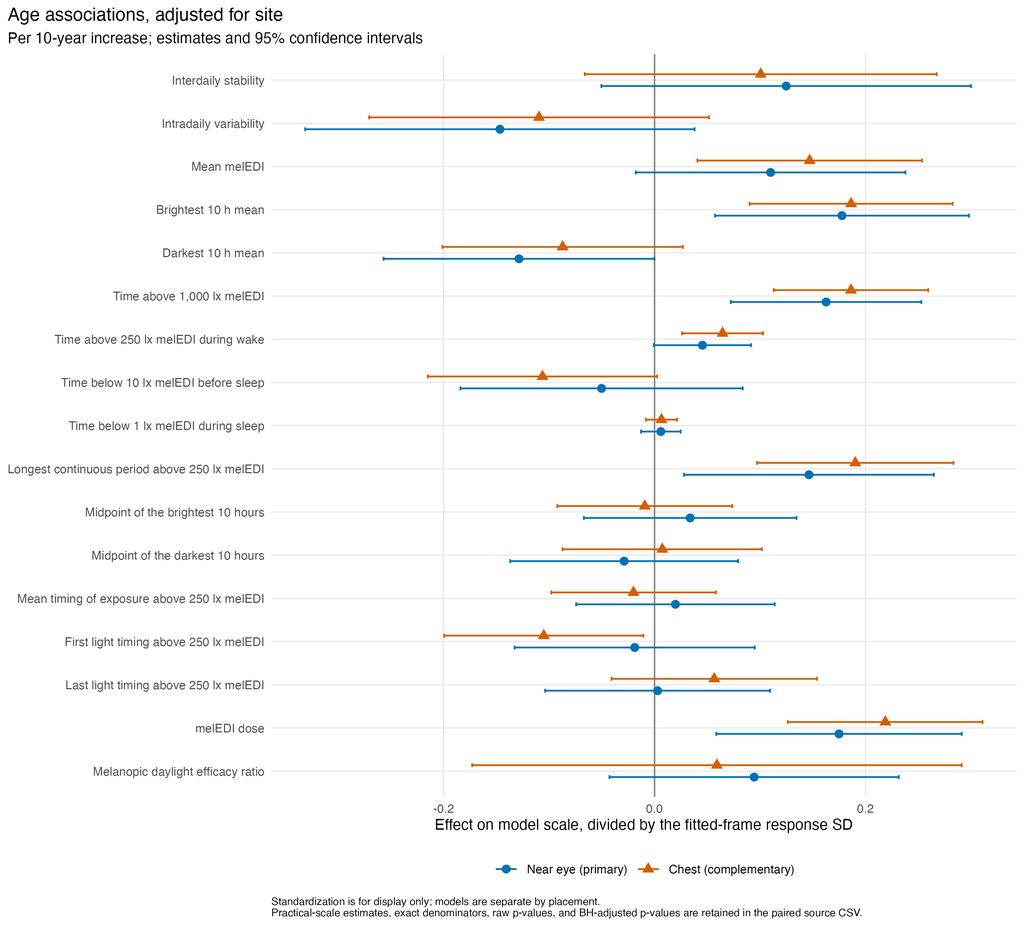

Site-adjusted age associations. Standardization is for display; practical estimates and exact samples are in the paired source CSV.

## 4.2 Measured biological sex

Near eye (primary): Measured biological sex, Female minus Male

| Metric | Effect (95% CI) | Raw p | BH-adjusted p | Sample | Valid support (h) | Assessment |
| --- | --- | --- | --- | --- | --- | --- |
| Interdaily stability | OR 1.07 (0.93–1.23) | 0.357 | 0.556 | 141 participants; 141 observations; 816 contributing participant-days | 18,851.0 | acceptable |
| Intradaily variability | -0.002 (-0.135–0.131) | 0.978 | 0.978 | 141 participants; 141 observations; 816 contributing participant-days | 18,851.0 | acceptable with specified limitations |
| Mean melEDI | 0.78× (0.62–0.99) | 0.036 | 0.206 | 141 participants; 816 participant-days/observations | 18,851.0 | acceptable |
| Brightest 10 h mean | 0.69× (0.49–0.98) | 0.031 | 0.206 | 141 participants; 816 participant-days/observations | not supplied for this metric window | acceptable |
| Darkest 10 h mean | 0.87× (0.72–1.04) | 0.109 | 0.266 | 141 participants; 816 participant-days/observations | not supplied for this metric window | acceptable with specified limitations |
| Time above 1,000 lx melEDI | 0.74× (0.57–0.96) | 0.023 | 0.206 | 141 participants; 816 participant-days/observations | 18,851.0 | acceptable |
| Time above 250 lx melEDI during wake | 0.81× (0.66–1.00) | 0.057 | 0.244 | 141 participants; 737 participant-days/observations | 9,174.3 | acceptable |
| Time below 10 lx melEDI before sleep | -3.4 min (-18.6–11.7) | 0.647 | 0.734 | 139 participants; 655 participant-days/observations | 1,925.5 | acceptable with specified limitations |
| Time below 1 lx melEDI during sleep | 1.05× (0.98–1.12) | 0.147 | 0.313 | 141 participants; 778 participant-days/observations | 6,282.5 | acceptable with specified limitations |
| Longest continuous period above 250 lx melEDI | 0.84× (0.69–1.03) | 0.089 | 0.266 | 141 participants; 816 participant-days/observations | 18,851.0 | acceptable |
| Midpoint of the brightest 10 hours | 0.5 min (-20.6–21.6) | 0.959 | 0.978 | 141 participants; 816 participant-days/observations | not supplied for this metric window | acceptable with specified limitations |
| Midpoint of the darkest 10 hours | 6.4 min (-14.8–27.6) | 0.537 | 0.652 | 141 participants; 816 participant-days/observations | not supplied for this metric window | acceptable with specified limitations |
| Mean timing of exposure above 250 lx melEDI | -8.9 min (-28.6–10.8) | 0.365 | 0.556 | 141 participants; 742 participant-days/observations | 17,209.6 | acceptable |
| First light timing above 250 lx melEDI | 13.1 min (-18.4–44.6) | 0.406 | 0.556 | 140 participants; 727 participant-days/observations | 16,832.5 | acceptable |
| Last light timing above 250 lx melEDI | -18.2 min (-49.1–12.8) | 0.235 | 0.444 | 141 participants; 687 participant-days/observations | 15,995.0 | acceptable |
| melEDI dose | 0.77× (0.55–1.07) | 0.108 | 0.266 | 141 participants; 761 participant-days/observations | 17,678.8 | acceptable |
| Melanopic daylight efficacy ratio | -0.012 (-0.041–0.018) | 0.425 | 0.556 | 137 participants; 702 participant-days/observations | 10,949.9 | acceptable with specified limitations |

Effects are model-based estimates with 95% confidence intervals. Bold adjusted p-values satisfy the explicitly labelled BH rule within the corresponding 17-member family.

No near-eye Female–Male comparison met the BH-adjusted main-effect rule. The largest fitted contrasts remain reported with their 95% CIs rather than being described as equivalent or absent.

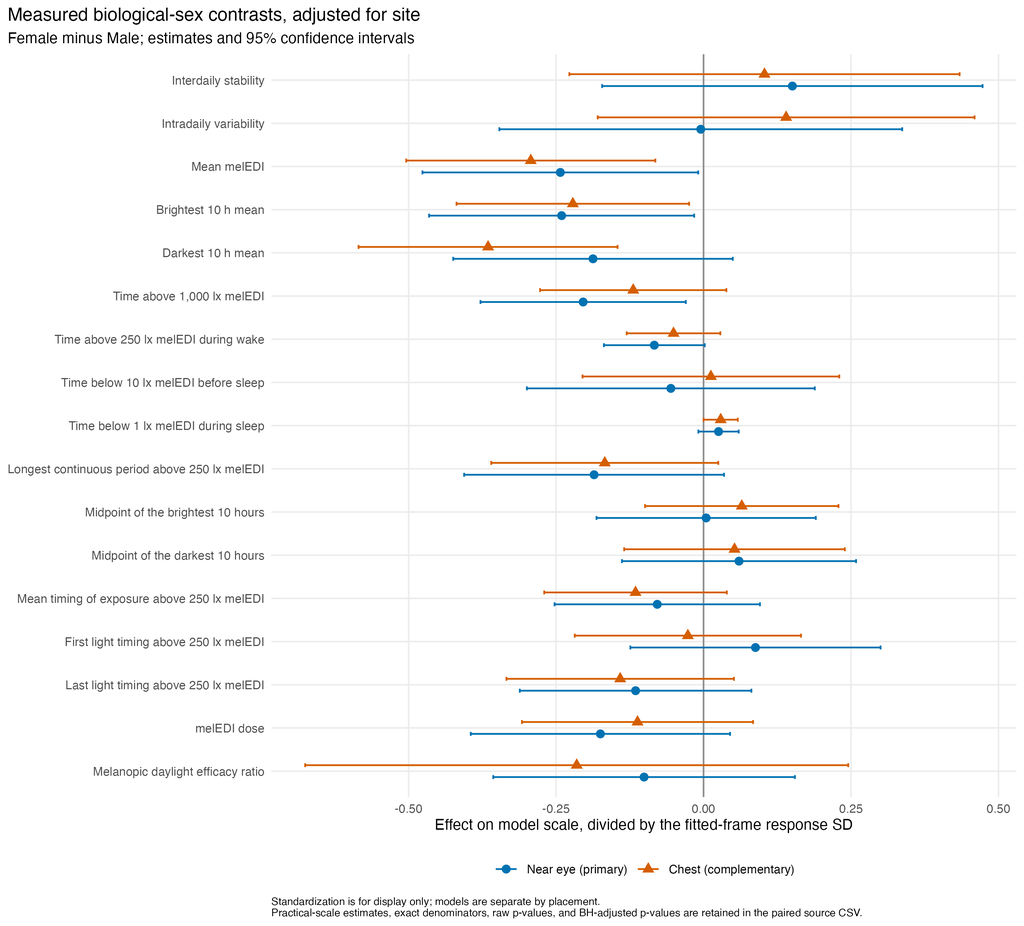

Site-adjusted measured biological-sex contrasts. Gender was not inferred or substituted.

# 5 Complementary chest results

## 5.1 Age

Chest (complementary): Age, per 10 years

| Metric | Effect (95% CI) | Raw p | BH-adjusted p | Sample | Valid support (h) | Assessment |
| --- | --- | --- | --- | --- | --- | --- |
| Interdaily stability | OR 1.04 (0.97–1.12) | 0.235 | 0.340 | 153 participants; 153 observations; 900 contributing participant-days | 20,845.4 | acceptable |
| Intradaily variability | -0.044 (-0.108–0.021) | 0.181 | 0.308 | 153 participants; 153 observations; 900 contributing participant-days | 20,845.4 | acceptable |
| Mean melEDI | 1.16× (1.04–1.30) | 0.006 | **0.017** | 154 participants; 902 participant-days/observations | 20,891.8 | acceptable with specified limitations |
| Brightest 10 h mean | 1.35× (1.15–1.57) | <0.001 | **<0.001** | 154 participants; 902 participant-days/observations | not supplied for this metric window | acceptable with specified limitations |
| Darkest 10 h mean | 0.94× (0.86–1.02) | 0.124 | 0.234 | 154 participants; 902 participant-days/observations | not supplied for this metric window | acceptable with specified limitations |
| Time above 1,000 lx melEDI | 1.31× (1.18–1.46) | <0.001 | **<0.001** | 154 participants; 902 participant-days/observations | 20,891.8 | acceptable |
| Time above 250 lx melEDI during wake | 1.16× (1.06–1.26) | 0.001 | **0.004** | 154 participants; 818 participant-days/observations | 10,297.7 | acceptable |
| Time below 10 lx melEDI before sleep | -6.3 min (-12.8–0.1) | 0.049 | 0.105 | 153 participants; 743 participant-days/observations | 2,180.1 | acceptable with specified limitations |
| Time below 1 lx melEDI during sleep | 1.01× (0.98–1.04) | 0.383 | 0.500 | 154 participants; 861 participant-days/observations | 6,871.4 | acceptable with specified limitations |
| Longest continuous period above 250 lx melEDI | 1.18× (1.09–1.27) | <0.001 | **<0.001** | 154 participants; 902 participant-days/observations | 20,891.8 | acceptable |
| Midpoint of the brightest 10 hours | -1.1 min (-10.9–8.7) | 0.825 | 0.873 | 154 participants; 902 participant-days/observations | not supplied for this metric window | acceptable with specified limitations |
| Midpoint of the darkest 10 hours | 0.8 min (-9.0–10.5) | 0.873 | 0.873 | 154 participants; 902 participant-days/observations | not supplied for this metric window | acceptable with specified limitations |
| Mean timing of exposure above 250 lx melEDI | -2.4 min (-11.6–6.9) | 0.615 | 0.697 | 154 participants; 831 participant-days/observations | 19,336.1 | acceptable |
| First light timing above 250 lx melEDI | -15.4 min (-29.3–-1.6) | 0.026 | 0.063 | 154 participants; 802 participant-days/observations | 18,634.7 | acceptable with specified limitations |
| Last light timing above 250 lx melEDI | 8.1 min (-5.8–22.0) | 0.240 | 0.340 | 154 participants; 787 participant-days/observations | 18,358.1 | acceptable with specified limitations |
| melEDI dose | 1.40× (1.21–1.61) | <0.001 | **<0.001** | 154 participants; 851 participant-days/observations | 19,814.9 | acceptable |
| Melanopic daylight efficacy ratio | 0.009 (-0.028–0.047) | 0.605 | 0.697 | 152 participants; 732 participant-days/observations | 11,145.3 | acceptable with specified limitations |

Effects are model-based estimates with 95% confidence intervals. Bold adjusted p-values satisfy the explicitly labelled BH rule within the corresponding 17-member family.

## 5.2 Measured biological sex

Chest (complementary): Measured biological sex, Female minus Male

| Metric | Effect (95% CI) | Raw p | BH-adjusted p | Sample | Valid support (h) | Assessment |
| --- | --- | --- | --- | --- | --- | --- |
| Interdaily stability | OR 1.04 (0.91–1.20) | 0.538 | 0.649 | 153 participants; 153 observations; 900 contributing participant-days | 20,845.4 | acceptable |
| Intradaily variability | 0.056 (-0.072–0.183) | 0.388 | 0.550 | 153 participants; 153 observations; 900 contributing participant-days | 20,845.4 | acceptable |
| Mean melEDI | 0.74× (0.60–0.92) | 0.006 | **0.048** | 154 participants; 902 participant-days/observations | 20,891.8 | acceptable with specified limitations |
| Brightest 10 h mean | 0.70× (0.51–0.96) | 0.024 | 0.139 | 154 participants; 902 participant-days/observations | not supplied for this metric window | acceptable with specified limitations |
| Darkest 10 h mean | 0.76× (0.65–0.90) | <0.001 | **0.016** | 154 participants; 902 participant-days/observations | not supplied for this metric window | acceptable with specified limitations |
| Time above 1,000 lx melEDI | 0.84× (0.67–1.06) | 0.140 | 0.303 | 154 participants; 902 participant-days/observations | 20,891.8 | acceptable with specified limitations |
| Time above 250 lx melEDI during wake | 0.89× (0.74–1.07) | 0.210 | 0.397 | 154 participants; 818 participant-days/observations | 10,297.7 | acceptable |
| Time below 10 lx melEDI before sleep | 0.7 min (-12.2–13.7) | 0.904 | 0.904 | 153 participants; 743 participant-days/observations | 2,180.1 | acceptable with specified limitations |
| Time below 1 lx melEDI during sleep | 1.06× (1.00–1.12) | 0.051 | 0.217 | 154 participants; 861 participant-days/observations | 6,871.4 | acceptable with specified limitations |
| Longest continuous period above 250 lx melEDI | 0.87× (0.73–1.02) | 0.081 | 0.274 | 154 participants; 902 participant-days/observations | 20,891.8 | acceptable |
| Midpoint of the brightest 10 hours | 7.7 min (-11.8–27.2) | 0.425 | 0.555 | 154 participants; 902 participant-days/observations | not supplied for this metric window | acceptable |
| Midpoint of the darkest 10 hours | 5.4 min (-13.9–24.8) | 0.572 | 0.649 | 154 participants; 902 participant-days/observations | not supplied for this metric window | acceptable with specified limitations |
| Mean timing of exposure above 250 lx melEDI | -13.6 min (-31.9–4.7) | 0.135 | 0.303 | 154 participants; 831 participant-days/observations | 19,336.1 | acceptable |
| First light timing above 250 lx melEDI | -3.9 min (-32.0–24.2) | 0.775 | 0.823 | 154 participants; 802 participant-days/observations | 18,634.7 | acceptable with specified limitations |
| Last light timing above 250 lx melEDI | -20.2 min (-47.8–7.4) | 0.143 | 0.303 | 154 participants; 787 participant-days/observations | 18,358.1 | acceptable with specified limitations |
| melEDI dose | 0.84× (0.63–1.14) | 0.251 | 0.428 | 154 participants; 851 participant-days/observations | 19,814.9 | acceptable with specified limitations |
| Melanopic daylight efficacy ratio | -0.035 (-0.108–0.039) | 0.347 | 0.537 | 152 participants; 732 participant-days/observations | 11,145.3 | acceptable with specified limitations |

Effects are model-based estimates with 95% confidence intervals. Bold adjusted p-values satisfy the explicitly labelled BH rule within the corresponding 17-member family.

The chest Female-to-Male ratios were 0.74 (95% CI 0.60–0.92; BH-adjusted p = 0.048) for mean melEDI and 0.76 (0.65–0.90; adjusted p = 0.016) for darkest-10-hour mean. These complementary findings do not supersede the primary near-eye placement.

# 6 Site heterogeneity

Two chest age-by-site comparisons met their separately labelled 17-member BH rule: midpoint of the brightest 10 hours (raw p = 0.004; adjusted p = 0.045) and last light timing above 250 lx melEDI (raw p = 0.005; adjusted p = 0.045). No near-eye interaction or biological-sex-by-site interaction met its adjusted rule.

All primary site-heterogeneity comparisons

| Placement | Metric | Comparison | Raw p | BH-adjusted p | Interpretation |
| --- | --- | --- | --- | --- | --- |
| Chest (complementary) | Interdaily stability | AGE-SITE | 0.065 | 0.121 | No multiplicity-adjusted evidence of site heterogeneity; site-specific estimates remain descriptive |
| Chest (complementary) | Intradaily variability | AGE-SITE | 0.332 | 0.353 | No multiplicity-adjusted evidence of site heterogeneity; site-specific estimates remain descriptive |
| Chest (complementary) | Mean melEDI | AGE-SITE | 0.012 | 0.054 | No multiplicity-adjusted evidence of site heterogeneity; site-specific estimates remain descriptive |
| Chest (complementary) | Brightest 10 h mean | AGE-SITE | 0.056 | 0.118 | No multiplicity-adjusted evidence of site heterogeneity; site-specific estimates remain descriptive |
| Chest (complementary) | Darkest 10 h mean | AGE-SITE | 0.096 | 0.143 | No multiplicity-adjusted evidence of site heterogeneity; site-specific estimates remain descriptive |
| Chest (complementary) | Time above 1,000 lx melEDI | AGE-SITE | 0.209 | 0.254 | No multiplicity-adjusted evidence of site heterogeneity; site-specific estimates remain descriptive |
| Chest (complementary) | Time above 250 lx melEDI during wake | AGE-SITE | 0.286 | 0.324 | No multiplicity-adjusted evidence of site heterogeneity; site-specific estimates remain descriptive |
| Chest (complementary) | Time below 10 lx melEDI before sleep | AGE-SITE | 0.048 | 0.117 | No multiplicity-adjusted evidence of site heterogeneity; site-specific estimates remain descriptive |
| Chest (complementary) | Time below 1 lx melEDI during sleep | AGE-SITE | 0.189 | 0.247 | No multiplicity-adjusted evidence of site heterogeneity; site-specific estimates remain descriptive |
| Chest (complementary) | Longest continuous period above 250 lx melEDI | AGE-SITE | 0.101 | 0.143 | No multiplicity-adjusted evidence of site heterogeneity; site-specific estimates remain descriptive |
| Chest (complementary) | Midpoint of the brightest 10 hours | AGE-SITE | 0.004 | **0.045** | Evidence of site heterogeneity under the labelled BH family; inspect all non-selective site-specific estimates |
| Chest (complementary) | Midpoint of the darkest 10 hours | AGE-SITE | 0.025 | 0.085 | No multiplicity-adjusted evidence of site heterogeneity; site-specific estimates remain descriptive |
| Chest (complementary) | Mean timing of exposure above 250 lx melEDI | AGE-SITE | 0.013 | 0.054 | No multiplicity-adjusted evidence of site heterogeneity; site-specific estimates remain descriptive |
| Chest (complementary) | First light timing above 250 lx melEDI | AGE-SITE | 0.032 | 0.091 | No multiplicity-adjusted evidence of site heterogeneity; site-specific estimates remain descriptive |
| Chest (complementary) | Last light timing above 250 lx melEDI | AGE-SITE | 0.005 | **0.045** | Evidence of site heterogeneity under the labelled BH family; inspect all non-selective site-specific estimates |
| Chest (complementary) | melEDI dose | AGE-SITE | 0.071 | 0.121 | No multiplicity-adjusted evidence of site heterogeneity; site-specific estimates remain descriptive |
| Chest (complementary) | Melanopic daylight efficacy ratio | AGE-SITE | 0.909 | 0.909 | No multiplicity-adjusted evidence of site heterogeneity; site-specific estimates remain descriptive |
| Chest (complementary) | Interdaily stability | SEX-SITE | 0.691 | 0.734 | No multiplicity-adjusted evidence of site heterogeneity; site-specific estimates remain descriptive |
| Chest (complementary) | Intradaily variability | SEX-SITE | 0.287 | 0.443 | No multiplicity-adjusted evidence of site heterogeneity; site-specific estimates remain descriptive |
| Chest (complementary) | Mean melEDI | SEX-SITE | 0.143 | 0.364 | No multiplicity-adjusted evidence of site heterogeneity; site-specific estimates remain descriptive |
| Chest (complementary) | Brightest 10 h mean | SEX-SITE | 0.045 | 0.364 | No multiplicity-adjusted evidence of site heterogeneity; site-specific estimates remain descriptive |
| Chest (complementary) | Darkest 10 h mean | SEX-SITE | 0.468 | 0.53 | No multiplicity-adjusted evidence of site heterogeneity; site-specific estimates remain descriptive |
| Chest (complementary) | Time above 1,000 lx melEDI | SEX-SITE | 0.081 | 0.364 | No multiplicity-adjusted evidence of site heterogeneity; site-specific estimates remain descriptive |
| Chest (complementary) | Time above 250 lx melEDI during wake | SEX-SITE | 0.267 | 0.443 | No multiplicity-adjusted evidence of site heterogeneity; site-specific estimates remain descriptive |
| Chest (complementary) | Time below 10 lx melEDI before sleep | SEX-SITE | 0.201 | 0.38 | No multiplicity-adjusted evidence of site heterogeneity; site-specific estimates remain descriptive |
| Chest (complementary) | Time below 1 lx melEDI during sleep | SEX-SITE | 0.796 | 0.796 | No multiplicity-adjusted evidence of site heterogeneity; site-specific estimates remain descriptive |
| Chest (complementary) | Longest continuous period above 250 lx melEDI | SEX-SITE | 0.378 | 0.475 | No multiplicity-adjusted evidence of site heterogeneity; site-specific estimates remain descriptive |
| Chest (complementary) | Midpoint of the brightest 10 hours | SEX-SITE | 0.099 | 0.364 | No multiplicity-adjusted evidence of site heterogeneity; site-specific estimates remain descriptive |
| Chest (complementary) | Midpoint of the darkest 10 hours | SEX-SITE | 0.385 | 0.475 | No multiplicity-adjusted evidence of site heterogeneity; site-specific estimates remain descriptive |
| Chest (complementary) | Mean timing of exposure above 250 lx melEDI | SEX-SITE | 0.187 | 0.38 | No multiplicity-adjusted evidence of site heterogeneity; site-specific estimates remain descriptive |
| Chest (complementary) | First light timing above 250 lx melEDI | SEX-SITE | 0.391 | 0.475 | No multiplicity-adjusted evidence of site heterogeneity; site-specific estimates remain descriptive |
| Chest (complementary) | Last light timing above 250 lx melEDI | SEX-SITE | 0.150 | 0.364 | No multiplicity-adjusted evidence of site heterogeneity; site-specific estimates remain descriptive |
| Chest (complementary) | melEDI dose | SEX-SITE | 0.112 | 0.364 | No multiplicity-adjusted evidence of site heterogeneity; site-specific estimates remain descriptive |
| Chest (complementary) | Melanopic daylight efficacy ratio | SEX-SITE | 0.108 | 0.364 | No multiplicity-adjusted evidence of site heterogeneity; site-specific estimates remain descriptive |
| Near eye (primary) | Interdaily stability | AGE-SITE | 0.958 | 0.958 | No multiplicity-adjusted evidence of site heterogeneity; site-specific estimates remain descriptive |
| Near eye (primary) | Intradaily variability | AGE-SITE | 0.622 | 0.661 | No multiplicity-adjusted evidence of site heterogeneity; site-specific estimates remain descriptive |
| Near eye (primary) | Mean melEDI | AGE-SITE | 0.077 | 0.248 | No multiplicity-adjusted evidence of site heterogeneity; site-specific estimates remain descriptive |
| Near eye (primary) | Brightest 10 h mean | AGE-SITE | 0.378 | 0.459 | No multiplicity-adjusted evidence of site heterogeneity; site-specific estimates remain descriptive |
| Near eye (primary) | Darkest 10 h mean | AGE-SITE | 0.047 | 0.248 | No multiplicity-adjusted evidence of site heterogeneity; site-specific estimates remain descriptive |
| Near eye (primary) | Time above 1,000 lx melEDI | AGE-SITE | 0.109 | 0.248 | No multiplicity-adjusted evidence of site heterogeneity; site-specific estimates remain descriptive |
| Near eye (primary) | Time above 250 lx melEDI during wake | AGE-SITE | 0.348 | 0.459 | No multiplicity-adjusted evidence of site heterogeneity; site-specific estimates remain descriptive |
| Near eye (primary) | Time below 10 lx melEDI before sleep | AGE-SITE | 0.087 | 0.248 | No multiplicity-adjusted evidence of site heterogeneity; site-specific estimates remain descriptive |
| Near eye (primary) | Time below 1 lx melEDI during sleep | AGE-SITE | 0.270 | 0.458 | No multiplicity-adjusted evidence of site heterogeneity; site-specific estimates remain descriptive |
| Near eye (primary) | Longest continuous period above 250 lx melEDI | AGE-SITE | 0.098 | 0.248 | No multiplicity-adjusted evidence of site heterogeneity; site-specific estimates remain descriptive |
| Near eye (primary) | Midpoint of the brightest 10 hours | AGE-SITE | 0.089 | 0.248 | No multiplicity-adjusted evidence of site heterogeneity; site-specific estimates remain descriptive |
| Near eye (primary) | Midpoint of the darkest 10 hours | AGE-SITE | 0.594 | 0.661 | No multiplicity-adjusted evidence of site heterogeneity; site-specific estimates remain descriptive |
| Near eye (primary) | Mean timing of exposure above 250 lx melEDI | AGE-SITE | 0.116 | 0.248 | No multiplicity-adjusted evidence of site heterogeneity; site-specific estimates remain descriptive |
| Near eye (primary) | First light timing above 250 lx melEDI | AGE-SITE | 0.152 | 0.287 | No multiplicity-adjusted evidence of site heterogeneity; site-specific estimates remain descriptive |
| Near eye (primary) | Last light timing above 250 lx melEDI | AGE-SITE | 0.117 | 0.248 | No multiplicity-adjusted evidence of site heterogeneity; site-specific estimates remain descriptive |
| Near eye (primary) | melEDI dose | AGE-SITE | 0.378 | 0.459 | No multiplicity-adjusted evidence of site heterogeneity; site-specific estimates remain descriptive |
| Near eye (primary) | Melanopic daylight efficacy ratio | AGE-SITE | 0.317 | 0.459 | No multiplicity-adjusted evidence of site heterogeneity; site-specific estimates remain descriptive |
| Near eye (primary) | Interdaily stability | SEX-SITE | 0.555 | 0.86 | No multiplicity-adjusted evidence of site heterogeneity; site-specific estimates remain descriptive |
| Near eye (primary) | Intradaily variability | SEX-SITE | 0.323 | 0.86 | No multiplicity-adjusted evidence of site heterogeneity; site-specific estimates remain descriptive |
| Near eye (primary) | Mean melEDI | SEX-SITE | 0.995 | 0.995 | No multiplicity-adjusted evidence of site heterogeneity; site-specific estimates remain descriptive |
| Near eye (primary) | Brightest 10 h mean | SEX-SITE | 0.751 | 0.86 | No multiplicity-adjusted evidence of site heterogeneity; site-specific estimates remain descriptive |
| Near eye (primary) | Darkest 10 h mean | SEX-SITE | 0.618 | 0.86 | No multiplicity-adjusted evidence of site heterogeneity; site-specific estimates remain descriptive |
| Near eye (primary) | Time above 1,000 lx melEDI | SEX-SITE | 0.455 | 0.86 | No multiplicity-adjusted evidence of site heterogeneity; site-specific estimates remain descriptive |
| Near eye (primary) | Time above 250 lx melEDI during wake | SEX-SITE | 0.302 | 0.86 | No multiplicity-adjusted evidence of site heterogeneity; site-specific estimates remain descriptive |
| Near eye (primary) | Time below 10 lx melEDI before sleep | SEX-SITE | 0.209 | 0.86 | No multiplicity-adjusted evidence of site heterogeneity; site-specific estimates remain descriptive |
| Near eye (primary) | Time below 1 lx melEDI during sleep | SEX-SITE | 0.356 | 0.86 | No multiplicity-adjusted evidence of site heterogeneity; site-specific estimates remain descriptive |
| Near eye (primary) | Longest continuous period above 250 lx melEDI | SEX-SITE | 0.246 | 0.86 | No multiplicity-adjusted evidence of site heterogeneity; site-specific estimates remain descriptive |
| Near eye (primary) | Midpoint of the brightest 10 hours | SEX-SITE | 0.694 | 0.86 | No multiplicity-adjusted evidence of site heterogeneity; site-specific estimates remain descriptive |
| Near eye (primary) | Midpoint of the darkest 10 hours | SEX-SITE | 0.759 | 0.86 | No multiplicity-adjusted evidence of site heterogeneity; site-specific estimates remain descriptive |
| Near eye (primary) | Mean timing of exposure above 250 lx melEDI | SEX-SITE | 0.533 | 0.86 | No multiplicity-adjusted evidence of site heterogeneity; site-specific estimates remain descriptive |
| Near eye (primary) | First light timing above 250 lx melEDI | SEX-SITE | 0.542 | 0.86 | No multiplicity-adjusted evidence of site heterogeneity; site-specific estimates remain descriptive |
| Near eye (primary) | Last light timing above 250 lx melEDI | SEX-SITE | 0.936 | 0.994 | No multiplicity-adjusted evidence of site heterogeneity; site-specific estimates remain descriptive |
| Near eye (primary) | melEDI dose | SEX-SITE | 0.537 | 0.86 | No multiplicity-adjusted evidence of site heterogeneity; site-specific estimates remain descriptive |
| Near eye (primary) | Melanopic daylight efficacy ratio | SEX-SITE | 0.641 | 0.86 | No multiplicity-adjusted evidence of site heterogeneity; site-specific estimates remain descriptive |

Bold values meet the explicitly labelled interaction-family rule.

All site-specific estimates for the two supported interactions are shown below; sites were not selected by the sign or size of their coefficient.

Non-selective site-specific age estimates

| Metric | Site | Difference per decade (95% CI) |
| --- | --- | --- |
| Midpoint of the brightest 10 hours | Borås (SE) | +17.9 min (-2.7 to +38.6) |
| Midpoint of the brightest 10 hours | Delft (NL) | +3.4 min (-20.5 to +27.3) |
| Midpoint of the brightest 10 hours | Dortmund (DE) | -1.2 min (-20.9 to +18.5) |
| Midpoint of the brightest 10 hours | Munich (DE) | +245.2 min (+105.6 to +384.9) |
| Midpoint of the brightest 10 hours | Madrid (ES) | -19.3 min (-42.1 to +3.6) |
| Midpoint of the brightest 10 hours | Izmir (TR) | +32.9 min (-64.6 to +130.4) |
| Midpoint of the brightest 10 hours | San José (CR) | -13.6 min (-33.7 to +6.5) |
| Midpoint of the brightest 10 hours | Kumasi (GH) | -57.9 min (-212.1 to +96.3) |
| Last light timing above 250 lx melEDI | Borås (SE) | +43.9 min (+14.8 to +73.1) |
| Last light timing above 250 lx melEDI | Delft (NL) | -29.6 min (-65.2 to +6.1) |
| Last light timing above 250 lx melEDI | Dortmund (DE) | -25.1 min (-52.8 to +2.6) |
| Last light timing above 250 lx melEDI | Munich (DE) | -39.4 min (-235.6 to +156.8) |
| Last light timing above 250 lx melEDI | Madrid (ES) | +35.7 min (+3.3 to +68.0) |
| Last light timing above 250 lx melEDI | Izmir (TR) | -27.3 min (-164.1 to +109.6) |
| Last light timing above 250 lx melEDI | San José (CR) | +14.7 min (-13.6 to +43.0) |
| Last light timing above 250 lx melEDI | Kumasi (GH) | -27.1 min (-247.6 to +193.4) |

Timing differences are in clock minutes per decade. These estimates describe heterogeneity and are not separate site-level significance tests.

# 7 Diagnostics and explicit acceptability

All 68 primary additive models (17 metrics × two predictors × two placements) converged, had positive-definite Hessians where applicable, had full-rank fixed-effect designs, were non-singular, and produced no fit warning. No model was classified **not acceptable for inference**. Twenty-five were acceptable without a declared limitation; 43 were acceptable with specified limitations.

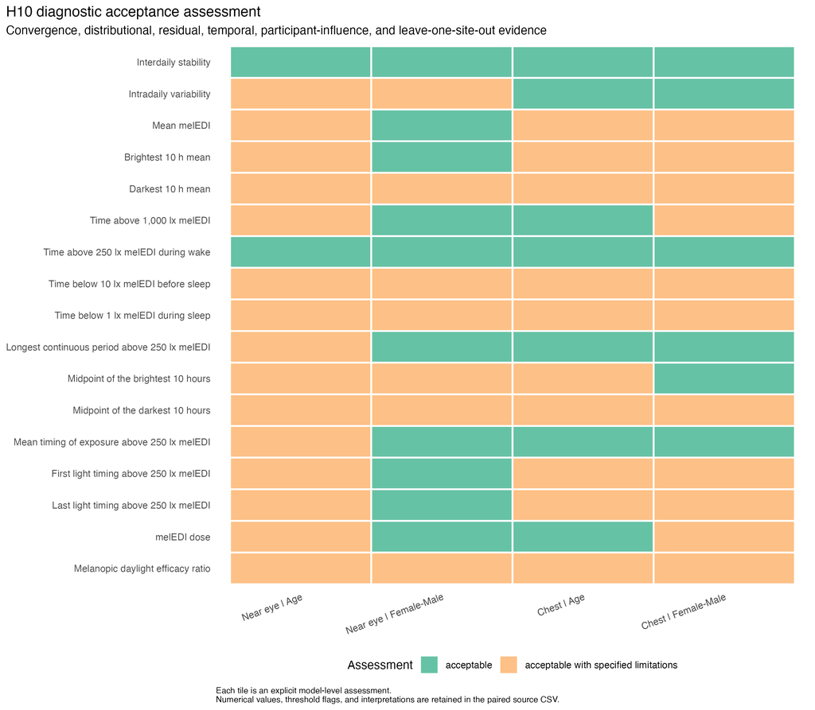

Model-level diagnostic assessments combining numerical, residual, distributional, temporal, and influence evidence.

The assessments were interpreted as follows:

- **Numerical and convergence:** 68/68 passed convergence, Hessian, rank, singularity, and warning gates.
- **Residual and distributional:** darkest-10-hour mean, near-eye darkest-10-hour midpoint, and MDER triggered one or both descriptive Q–Q/spread thresholds. For TBT1, four observed zeros at each placement materially exceeded the fitted Tweedie zero mass; the analytical standardized differences were 467–546. Those models remain acceptable only with this distributional limitation.
- **Temporal:** all 60 participant-day models passed the consecutive-day residual screen; the largest absolute pooled correlation was 0.239, below the declared 0.30 review threshold. The eight participant-level models were correctly marked not applicable.
- **Participant influence:** deleting the participant with the largest residual screen changed no estimate by one full-model standard error; the largest change was 0.439 standard errors. All 68 participant-deletion checks passed.
- **Site influence:** 35/68 models were marked acceptable with limitations because at least one leave-one-site-out refit changed adjusted support, reversed a small coefficient, or moved the coefficient by at least one full-model standard error. The largest shift was 1.72 standard errors. All leave-one-site-out fits remained estimable and converged.

Models acceptable with specified limitations

| Placement | Association | Metric | Residual/distribution flag | Serial check | Participant deletion | Site influence | Assessment |
| --- | --- | --- | --- | --- | --- | --- | --- |
| Chest (complementary) | Age, per 10 years | Mean melEDI | none | PASS DESCRIPTIVE CHECK | PASS DESCRIPTIVE CHECK | acceptable with specified limitations | acceptable with specified limitations |
| Chest (complementary) | Age, per 10 years | Brightest 10 h mean | none | PASS DESCRIPTIVE CHECK | PASS DESCRIPTIVE CHECK | acceptable with specified limitations | acceptable with specified limitations |
| Chest (complementary) | Age, per 10 years | Darkest 10 h mean | RESIDUAL SPREAD REVIEW | PASS DESCRIPTIVE CHECK | PASS DESCRIPTIVE CHECK | acceptable | acceptable with specified limitations |
| Chest (complementary) | Age, per 10 years | Time below 10 lx melEDI before sleep | none | PASS DESCRIPTIVE CHECK | PASS DESCRIPTIVE CHECK | acceptable with specified limitations | acceptable with specified limitations |
| Chest (complementary) | Age, per 10 years | Time below 1 lx melEDI during sleep | ZERO MASS REVIEW | PASS DESCRIPTIVE CHECK | PASS DESCRIPTIVE CHECK | acceptable | acceptable with specified limitations |
| Chest (complementary) | Age, per 10 years | Midpoint of the brightest 10 hours | none | PASS DESCRIPTIVE CHECK | PASS DESCRIPTIVE CHECK | acceptable with specified limitations | acceptable with specified limitations |
| Chest (complementary) | Age, per 10 years | Midpoint of the darkest 10 hours | none | PASS DESCRIPTIVE CHECK | PASS DESCRIPTIVE CHECK | acceptable with specified limitations | acceptable with specified limitations |
| Chest (complementary) | Age, per 10 years | First light timing above 250 lx melEDI | none | PASS DESCRIPTIVE CHECK | PASS DESCRIPTIVE CHECK | acceptable with specified limitations | acceptable with specified limitations |
| Chest (complementary) | Age, per 10 years | Last light timing above 250 lx melEDI | none | PASS DESCRIPTIVE CHECK | PASS DESCRIPTIVE CHECK | acceptable with specified limitations | acceptable with specified limitations |
| Chest (complementary) | Age, per 10 years | Melanopic daylight efficacy ratio | RESIDUAL QQ REVIEW | PASS DESCRIPTIVE CHECK | PASS DESCRIPTIVE CHECK | acceptable | acceptable with specified limitations |
| Chest (complementary) | Measured biological sex, Female minus Male | Mean melEDI | none | PASS DESCRIPTIVE CHECK | PASS DESCRIPTIVE CHECK | acceptable with specified limitations | acceptable with specified limitations |
| Chest (complementary) | Measured biological sex, Female minus Male | Brightest 10 h mean | none | PASS DESCRIPTIVE CHECK | PASS DESCRIPTIVE CHECK | acceptable with specified limitations | acceptable with specified limitations |
| Chest (complementary) | Measured biological sex, Female minus Male | Darkest 10 h mean | RESIDUAL SPREAD REVIEW | PASS DESCRIPTIVE CHECK | PASS DESCRIPTIVE CHECK | acceptable with specified limitations | acceptable with specified limitations |
| Chest (complementary) | Measured biological sex, Female minus Male | Time above 1,000 lx melEDI | none | PASS DESCRIPTIVE CHECK | PASS DESCRIPTIVE CHECK | acceptable with specified limitations | acceptable with specified limitations |
| Chest (complementary) | Measured biological sex, Female minus Male | Time below 10 lx melEDI before sleep | none | PASS DESCRIPTIVE CHECK | PASS DESCRIPTIVE CHECK | acceptable with specified limitations | acceptable with specified limitations |
| Chest (complementary) | Measured biological sex, Female minus Male | Time below 1 lx melEDI during sleep | ZERO MASS REVIEW | PASS DESCRIPTIVE CHECK | PASS DESCRIPTIVE CHECK | acceptable | acceptable with specified limitations |
| Chest (complementary) | Measured biological sex, Female minus Male | Midpoint of the darkest 10 hours | none | PASS DESCRIPTIVE CHECK | PASS DESCRIPTIVE CHECK | acceptable with specified limitations | acceptable with specified limitations |
| Chest (complementary) | Measured biological sex, Female minus Male | First light timing above 250 lx melEDI | none | PASS DESCRIPTIVE CHECK | PASS DESCRIPTIVE CHECK | acceptable with specified limitations | acceptable with specified limitations |
| Chest (complementary) | Measured biological sex, Female minus Male | Last light timing above 250 lx melEDI | none | PASS DESCRIPTIVE CHECK | PASS DESCRIPTIVE CHECK | acceptable with specified limitations | acceptable with specified limitations |
| Chest (complementary) | Measured biological sex, Female minus Male | melEDI dose | none | PASS DESCRIPTIVE CHECK | PASS DESCRIPTIVE CHECK | acceptable with specified limitations | acceptable with specified limitations |
| Chest (complementary) | Measured biological sex, Female minus Male | Melanopic daylight efficacy ratio | RESIDUAL QQ REVIEW | PASS DESCRIPTIVE CHECK | PASS DESCRIPTIVE CHECK | acceptable with specified limitations | acceptable with specified limitations |
| Near eye (primary) | Age, per 10 years | Intradaily variability | none | NOT APPLICABLE PARTICIPANT LEVEL | PASS DESCRIPTIVE CHECK | acceptable with specified limitations | acceptable with specified limitations |
| Near eye (primary) | Age, per 10 years | Mean melEDI | none | PASS DESCRIPTIVE CHECK | PASS DESCRIPTIVE CHECK | acceptable with specified limitations | acceptable with specified limitations |
| Near eye (primary) | Age, per 10 years | Brightest 10 h mean | none | PASS DESCRIPTIVE CHECK | PASS DESCRIPTIVE CHECK | acceptable with specified limitations | acceptable with specified limitations |
| Near eye (primary) | Age, per 10 years | Darkest 10 h mean | RESIDUAL SPREAD REVIEW | PASS DESCRIPTIVE CHECK | PASS DESCRIPTIVE CHECK | acceptable with specified limitations | acceptable with specified limitations |
| Near eye (primary) | Age, per 10 years | Time above 1,000 lx melEDI | none | PASS DESCRIPTIVE CHECK | PASS DESCRIPTIVE CHECK | acceptable with specified limitations | acceptable with specified limitations |
| Near eye (primary) | Age, per 10 years | Time below 10 lx melEDI before sleep | none | PASS DESCRIPTIVE CHECK | PASS DESCRIPTIVE CHECK | acceptable with specified limitations | acceptable with specified limitations |
| Near eye (primary) | Age, per 10 years | Time below 1 lx melEDI during sleep | ZERO MASS REVIEW | PASS DESCRIPTIVE CHECK | PASS DESCRIPTIVE CHECK | acceptable with specified limitations | acceptable with specified limitations |
| Near eye (primary) | Age, per 10 years | Longest continuous period above 250 lx melEDI | none | PASS DESCRIPTIVE CHECK | PASS DESCRIPTIVE CHECK | acceptable with specified limitations | acceptable with specified limitations |
| Near eye (primary) | Age, per 10 years | Midpoint of the brightest 10 hours | none | PASS DESCRIPTIVE CHECK | PASS DESCRIPTIVE CHECK | acceptable with specified limitations | acceptable with specified limitations |
| Near eye (primary) | Age, per 10 years | Midpoint of the darkest 10 hours | RESIDUAL QQ REVIEW | PASS DESCRIPTIVE CHECK | PASS DESCRIPTIVE CHECK | acceptable with specified limitations | acceptable with specified limitations |
| Near eye (primary) | Age, per 10 years | Mean timing of exposure above 250 lx melEDI | none | PASS DESCRIPTIVE CHECK | PASS DESCRIPTIVE CHECK | acceptable with specified limitations | acceptable with specified limitations |
| Near eye (primary) | Age, per 10 years | First light timing above 250 lx melEDI | none | PASS DESCRIPTIVE CHECK | PASS DESCRIPTIVE CHECK | acceptable with specified limitations | acceptable with specified limitations |
| Near eye (primary) | Age, per 10 years | Last light timing above 250 lx melEDI | none | PASS DESCRIPTIVE CHECK | PASS DESCRIPTIVE CHECK | acceptable with specified limitations | acceptable with specified limitations |
| Near eye (primary) | Age, per 10 years | melEDI dose | none | PASS DESCRIPTIVE CHECK | PASS DESCRIPTIVE CHECK | acceptable with specified limitations | acceptable with specified limitations |
| Near eye (primary) | Age, per 10 years | Melanopic daylight efficacy ratio | RESIDUAL QQ REVIEW | PASS DESCRIPTIVE CHECK | PASS DESCRIPTIVE CHECK | acceptable with specified limitations | acceptable with specified limitations |
| Near eye (primary) | Measured biological sex, Female minus Male | Intradaily variability | none | NOT APPLICABLE PARTICIPANT LEVEL | PASS DESCRIPTIVE CHECK | acceptable with specified limitations | acceptable with specified limitations |
| Near eye (primary) | Measured biological sex, Female minus Male | Darkest 10 h mean | RESIDUAL SPREAD REVIEW | PASS DESCRIPTIVE CHECK | PASS DESCRIPTIVE CHECK | acceptable | acceptable with specified limitations |
| Near eye (primary) | Measured biological sex, Female minus Male | Time below 10 lx melEDI before sleep | none | PASS DESCRIPTIVE CHECK | PASS DESCRIPTIVE CHECK | acceptable with specified limitations | acceptable with specified limitations |
| Near eye (primary) | Measured biological sex, Female minus Male | Time below 1 lx melEDI during sleep | ZERO MASS REVIEW | PASS DESCRIPTIVE CHECK | PASS DESCRIPTIVE CHECK | acceptable | acceptable with specified limitations |
| Near eye (primary) | Measured biological sex, Female minus Male | Midpoint of the brightest 10 hours | none | PASS DESCRIPTIVE CHECK | PASS DESCRIPTIVE CHECK | acceptable with specified limitations | acceptable with specified limitations |
| Near eye (primary) | Measured biological sex, Female minus Male | Midpoint of the darkest 10 hours | RESIDUAL QQ REVIEW | PASS DESCRIPTIVE CHECK | PASS DESCRIPTIVE CHECK | acceptable | acceptable with specified limitations |
| Near eye (primary) | Measured biological sex, Female minus Male | Melanopic daylight efficacy ratio | RESIDUAL QQ REVIEW | PASS DESCRIPTIVE CHECK | PASS DESCRIPTIVE CHECK | acceptable | acceptable with specified limitations |

Full numerical values and interpreted sentences are in H10_primary_diagnostic_assessment.csv.

# 8 Sensitivities

## 8.1 Placement-matched participant-day evidence

For each of the 15 participant-day metrics, near-eye and chest models were fitted separately on identical participant-day keys. Every key hash matched. Participant-level IS and IV remained unavailable because no current artifact recomputes them on identical paired participant-day sets; H10 did not approximate them.

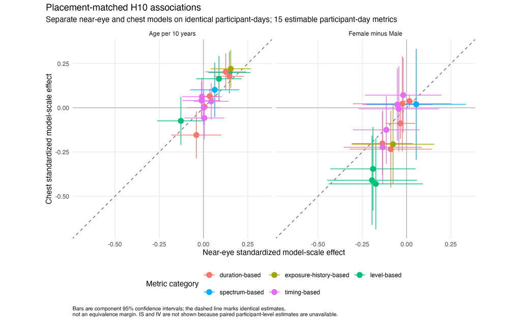

Placement-matched estimates. The identity line is descriptive and is not an equivalence margin.

On paired participant-days, the primary near-eye TAT1000 age association retained BH-adjusted support; near-eye M10mean and dose retained their positive directions but not adjusted support. All eight complementary chest primary main findings retained their directions and adjusted support. The paired analysis also supported chest pre-sleep TBT10 for age and chest M10mean for measured biological sex; these are sensitivity-only findings and do not replace the all-available primary contract.

## 8.2 Primary versus gap-timing-unaware values on common samples

All 34 placement-by-metric key sets matched exactly between datasets before refitting. Each primary adjusted finding retained its direction and adjusted support under the all-available gap-timing-unaware analysis. On exact common samples, all retained direction; chest mean melEDI for measured biological sex lost adjusted support in the primary common subset but regained it in the corresponding gap-timing-unaware subset.

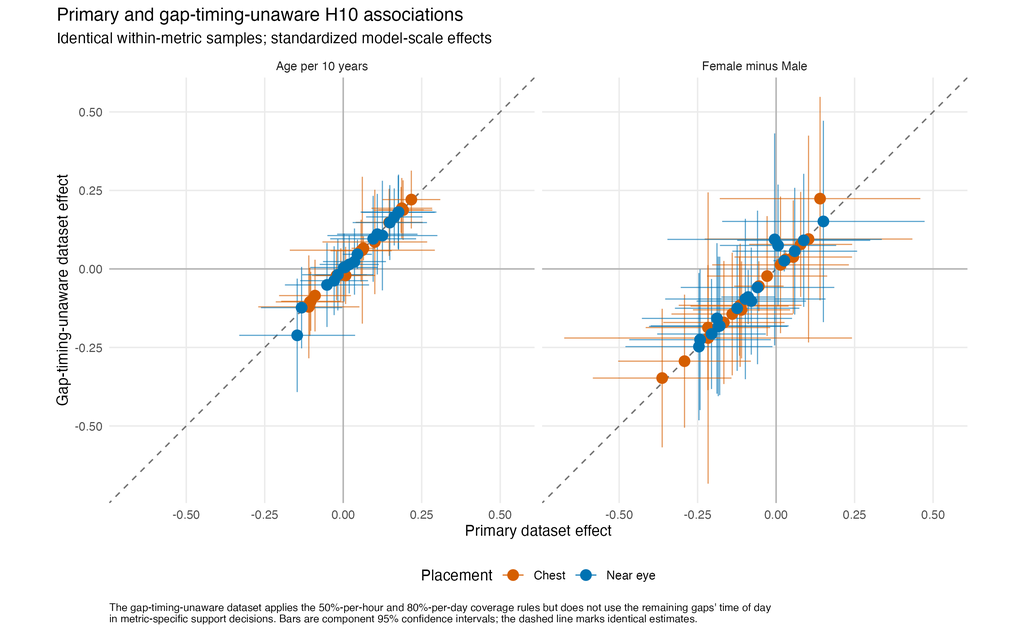

Primary and gap-timing-unaware estimates on identical within-metric samples.

## 8.3 Preregistration exclusions

The documented sensitivity removed nine participants: one older than 65 years, two recorded as not employed, and seven recorded as marginally employed; the 68-year-old participant was also one of the two not-employed participants. Students and trainees were not removed solely for that status. Every primary adjusted main finding retained its direction and adjusted support.

Participants removed in the preregistration-exclusion sensitivity

| Site | Participant | Age | Employment status |
| --- | --- | --- | --- |
| BAUA | BAUA_S013 | 62 | Marginally employed (Minijob) |
| FUSPCEU | FUSPCEU_S004 | 22 | Marginally employed (Minijob) |
| KNUST | KNUST_S007 | 22 | Not employed |
| KNUST | KNUST_S011 | 25 | Marginally employed (Minijob) |
| RISE | RISE_S012 | 68 | Not employed |
| THUAS | THUAS_S007 | 26 | Marginally employed (Minijob) |
| UCR | UCR_S008 | 37 | Marginally employed (Minijob) |
| UCR | UCR_S016 | 25 | Marginally employed (Minijob) |
| UCR | UCR_S021 | 25 | Marginally employed (Minijob) |

Nine unique participants; construct labels are reproduced from the normalized demographic input.

## 8.4 Metric-specific checks

- Restricting the longest continuous period above 250 lx melEDI to exactly identified periods retained positive age coefficients at both placements (near eye: 500 participant-days, 132 participants, raw p = 0.003; chest: 564 participant-days, 150 participants, raw p <0.001). These declared metric sensitivities did not create a new multiplicity decision.
- Moving the darkest-10-hour midpoint unwrap threshold from 16:00 to noon did not reveal an age or biological-sex association (all raw p ≥0.597).
- Current MDER showed right-skewed upper tails, most strongly at chest (primary maximum 3.574; 99th percentile 1.078). All four primary MDER models passed convergence, temporal, fitted-bound, and participant-deletion checks. They were acceptable with specified residual Q–Q limitations; two also carried a leave-one-site-out limitation. No current MDER age or Female–Male association met its 17-metric BH rule.
- A waking-only MDER sensitivity was unavailable: no approved current artifact derives it, and upstream recomputation was not authorized.

Declared metric-specific sensitivities

| Sensitivity | Placement | Association | Metric | Model-scale effect (95% CI) | Raw p | Sample |
| --- | --- | --- | --- | --- | --- | --- |
| exactly identified longest period | Chest (complementary) | Age, per 10 years | Longest continuous period above 250 lx melEDI | +0.077 (+0.038 to +0.115) | <0.001 | 150 participants; 564 observations |
| exactly identified longest period | Chest (complementary) | Measured biological sex, Female minus Male | Longest continuous period above 250 lx melEDI | -0.065 (-0.146 to +0.017) | 0.107 | 150 participants; 564 observations |
| exactly identified longest period | Near eye (primary) | Age, per 10 years | Longest continuous period above 250 lx melEDI | +0.073 (+0.024 to +0.123) | 0.003 | 132 participants; 500 observations |
| exactly identified longest period | Near eye (primary) | Measured biological sex, Female minus Male | Longest continuous period above 250 lx melEDI | -0.054 (-0.151 to +0.043) | 0.248 | 132 participants; 500 observations |
| l10 midnight unwrap noon | Chest (complementary) | Age, per 10 years | Midpoint of the darkest 10 hours | -0.665 (-10.177 to +8.848) | 0.891 | 154 participants; 902 observations |
| l10 midnight unwrap noon | Chest (complementary) | Measured biological sex, Female minus Male | Midpoint of the darkest 10 hours | +0.903 (-17.943 to +19.748) | 0.923 | 154 participants; 902 observations |
| l10 midnight unwrap noon | Near eye (primary) | Age, per 10 years | Midpoint of the darkest 10 hours | -1.080 (-12.842 to +10.683) | 0.854 | 141 participants; 816 observations |
| l10 midnight unwrap noon | Near eye (primary) | Measured biological sex, Female minus Male | Midpoint of the darkest 10 hours | +5.574 (-16.039 to +27.187) | 0.597 | 141 participants; 816 observations |

Raw p-values are shown descriptively; no new multiplicity decision was introduced.

The primary MDER sample contained 702 participant-days from 137 participants near eye and 732 participant-days from 152 participants at chest. The repaired same-estimand gap-timing-unaware comparator contained 687 participant-days from 137 participants near eye and 723 participant-days from 152 participants at chest. Its near-eye age coefficient was +0.011 MDER units per decade (95% CI -0.005 to +0.027; raw *p* = 0.155; BH-adjusted *p* = 0.264). All finite comparator MDER values were strictly positive. `THUAS_S002`, 2025-03-09 at chest had zero viable momentary-ratio minutes and is now reason-coded missing rather than stored as zero under FIND-049/CHG-101.

Current MDER associations

| Dataset | Placement | Association | Difference (95% CI) | Raw p | BH-adjusted p | Sample |
| --- | --- | --- | --- | --- | --- | --- |
| Gap-timing-unaware | Chest (complementary) | Age, per 10 years | +0.010 (-0.028 to +0.048) | 0.604 | 0.685 | 152 participants; 723 participant-days/observations |
| Gap-timing-unaware | Chest (complementary) | Measured biological sex, Female minus Male | -0.036 (-0.112 to +0.040) | 0.340 | 0.482 | 152 participants; 723 participant-days/observations |
| Gap-timing-unaware | Near eye (primary) | Age, per 10 years | +0.011 (-0.005 to +0.027) | 0.155 | 0.264 | 137 participants; 687 participant-days/observations |
| Gap-timing-unaware | Near eye (primary) | Measured biological sex, Female minus Male | -0.011 (-0.041 to +0.018) | 0.449 | 0.587 | 137 participants; 687 participant-days/observations |
| Primary | Chest (complementary) | Age, per 10 years | +0.009 (-0.028 to +0.047) | 0.605 | 0.697 | 152 participants; 732 participant-days/observations |
| Primary | Chest (complementary) | Measured biological sex, Female minus Male | -0.035 (-0.108 to +0.039) | 0.347 | 0.537 | 152 participants; 732 participant-days/observations |
| Primary | Near eye (primary) | Age, per 10 years | +0.011 (-0.005 to +0.027) | 0.163 | 0.277 | 137 participants; 702 participant-days/observations |
| Primary | Near eye (primary) | Measured biological sex, Female minus Male | -0.012 (-0.041 to +0.018) | 0.425 | 0.556 | 137 participants; 702 participant-days/observations |

Differences are in MDER units per decade or Female minus Male. No adjusted value met its separately labelled 17-metric BH rule.

Current MDER distribution and provenance assessment

| Dataset | Placement | Observations | Participants | Mean; median | Minimum; 99th percentile; maximum | Nonpositive values | Assessment |
| --- | --- | --- | --- | --- | --- | --- | --- |
| Gap-timing-unaware | Chest (complementary) | 723 | 152 | 0.757; 0.750 | 0.423; 1.079; 3.645 | 0 | Strong upper tail; interpret with participant and site influence checks |
| Gap-timing-unaware | Near eye (primary) | 687 | 137 | 0.724; 0.724 | 0.385; 0.975; 1.857 | 0 | Moderate upper tail; interpret with participant and site influence checks |
| Primary | Chest (complementary) | 732 | 152 | 0.757; 0.749 | 0.423; 1.078; 3.574 | 0 | Strong upper tail; interpret with participant and site influence checks |
| Primary | Near eye (primary) | 702 | 137 | 0.724; 0.724 | 0.385; 0.973; 1.857 | 0 | Moderate upper tail; interpret with participant and site influence checks |

Distribution summaries are interpreted jointly with the stored participant-deletion and leave-one-site-out results; they are not post-hoc exclusion rules.

Current MDER sample and preparation comparisons

| Comparison | Dataset | Placement | Association | Difference (95% CI) | Raw p | BH-adjusted p | Sample |
| --- | --- | --- | --- | --- | --- | --- | --- |
| Placement-matched | Gap-timing-unaware | Chest (complementary) | Age, per 10 years | +0.012 (-0.006 to +0.030) | 0.173 | 0.326 | 107 participants; 478 participant-days/observations |
| Placement-matched | Gap-timing-unaware | Chest (complementary) | Measured biological sex, Female minus Male | +0.002 (-0.035 to +0.038) | 0.906 | 1.000 | 107 participants; 478 participant-days/observations |
| Placement-matched | Gap-timing-unaware | Near eye (primary) | Age, per 10 years | +0.007 (-0.009 to +0.023) | 0.356 | 0.673 | 107 participants; 478 participant-days/observations |
| Placement-matched | Gap-timing-unaware | Near eye (primary) | Measured biological sex, Female minus Male | +0.007 (-0.026 to +0.040) | 0.650 | 0.850 | 107 participants; 478 participant-days/observations |
| Placement-matched | Primary | Chest (complementary) | Age, per 10 years | +0.012 (-0.006 to +0.029) | 0.180 | 0.382 | 107 participants; 489 participant-days/observations |
| Placement-matched | Primary | Chest (complementary) | Measured biological sex, Female minus Male | +0.002 (-0.034 to +0.038) | 0.888 | 1.000 | 107 participants; 489 participant-days/observations |
| Placement-matched | Primary | Near eye (primary) | Age, per 10 years | +0.007 (-0.009 to +0.023) | 0.353 | 0.681 | 107 participants; 489 participant-days/observations |
| Placement-matched | Primary | Near eye (primary) | Measured biological sex, Female minus Male | +0.006 (-0.026 to +0.039) | 0.686 | 0.899 | 107 participants; 489 participant-days/observations |
| Preregistration exclusions | Primary | Chest (complementary) | Age, per 10 years | +0.010 (-0.007 to +0.026) | 0.253 | 0.391 | 143 participants; 693 participant-days/observations |
| Preregistration exclusions | Primary | Chest (complementary) | Measured biological sex, Female minus Male | -0.002 (-0.034 to +0.030) | 0.908 | 0.908 | 143 participants; 693 participant-days/observations |
| Preregistration exclusions | Primary | Near eye (primary) | Age, per 10 years | +0.009 (-0.008 to +0.026) | 0.266 | 0.502 | 131 participants; 675 participant-days/observations |
| Preregistration exclusions | Primary | Near eye (primary) | Measured biological sex, Female minus Male | -0.014 (-0.044 to +0.016) | 0.337 | 0.574 | 131 participants; 675 participant-days/observations |
| Primary/gap exact common sample | Gap-timing-unaware | Chest (complementary) | Age, per 10 years | +0.010 (-0.028 to +0.048) | 0.604 | 0.659 | 152 participants; 723 participant-days/observations |
| Primary/gap exact common sample | Gap-timing-unaware | Chest (complementary) | Measured biological sex, Female minus Male | -0.036 (-0.112 to +0.040) | 0.340 | 0.453 | 152 participants; 723 participant-days/observations |
| Primary/gap exact common sample | Gap-timing-unaware | Near eye (primary) | Age, per 10 years | +0.011 (-0.005 to +0.027) | 0.155 | 0.293 | 137 participants; 687 participant-days/observations |
| Primary/gap exact common sample | Gap-timing-unaware | Near eye (primary) | Measured biological sex, Female minus Male | -0.011 (-0.041 to +0.018) | 0.449 | 0.545 | 137 participants; 687 participant-days/observations |
| Primary/gap exact common sample | Primary | Chest (complementary) | Age, per 10 years | +0.010 (-0.027 to +0.047) | 0.592 | 0.671 | 152 participants; 723 participant-days/observations |
| Primary/gap exact common sample | Primary | Chest (complementary) | Measured biological sex, Female minus Male | -0.035 (-0.109 to +0.039) | 0.342 | 0.484 | 152 participants; 723 participant-days/observations |
| Primary/gap exact common sample | Primary | Near eye (primary) | Age, per 10 years | +0.011 (-0.005 to +0.027) | 0.158 | 0.274 | 137 participants; 687 participant-days/observations |
| Primary/gap exact common sample | Primary | Near eye (primary) | Measured biological sex, Female minus Male | -0.011 (-0.041 to +0.018) | 0.438 | 0.573 | 137 participants; 687 participant-days/observations |

Every MDER-dependent accepted comparison is shown with its 95% CI, exact fitted sample, and complete-family adjusted p-value. None met its labelled BH rule.

## 8.5 Stability summary

All 11 primary adjusted main findings were directionally stable across every available approved sample and dataset sensitivity. Eight also retained adjusted support in every available comparison. The three with support changes were near-eye M10mean, near-eye dose, and chest mean melEDI for measured biological sex; their signs did not change.

Stability of primary adjusted main findings

| Placement | Association | Metric | Primary supported | Gap all-available | Paired/common | Preregistration exclusions | Classification |
| --- | --- | --- | --- | --- | --- | --- | --- |
| Chest (complementary) | Age, per 10 years | Mean melEDI | Yes | Yes | Yes | Yes | direction and adjusted-support stable |
| Chest (complementary) | Age, per 10 years | Brightest 10 h mean | Yes | Yes | Yes | Yes | direction and adjusted-support stable |
| Chest (complementary) | Age, per 10 years | Time above 1,000 lx melEDI | Yes | Yes | Yes | Yes | direction and adjusted-support stable |
| Chest (complementary) | Age, per 10 years | Time above 250 lx melEDI during wake | Yes | Yes | Yes | Yes | direction and adjusted-support stable |
| Chest (complementary) | Age, per 10 years | Longest continuous period above 250 lx melEDI | Yes | Yes | Yes | Yes | direction and adjusted-support stable |
| Chest (complementary) | Age, per 10 years | melEDI dose | Yes | Yes | Yes | Yes | direction and adjusted-support stable |
| Chest (complementary) | Measured biological sex, Female minus Male | Mean melEDI | Yes | Yes | Yes | Yes | direction stable; adjusted support changes |
| Chest (complementary) | Measured biological sex, Female minus Male | Darkest 10 h mean | Yes | Yes | Yes | Yes | direction and adjusted-support stable |
| Near eye (primary) | Age, per 10 years | Brightest 10 h mean | Yes | Yes | No | Yes | direction stable; adjusted support changes |
| Near eye (primary) | Age, per 10 years | Time above 1,000 lx melEDI | Yes | Yes | Yes | Yes | direction and adjusted-support stable |
| Near eye (primary) | Age, per 10 years | melEDI dose | Yes | Yes | No | Yes | direction stable; adjusted support changes |

Support refers to the scenario’s labelled 17-member BH family; direction was checked on the model scale.

# 9 Frozen V0 reconstruction and comparison

V0 used older 811-day near-eye and 897-day chest inputs. It fitted age, measured-sex, and age-by-site structures, but applied `p.adjust()` separately to each scalar p-value with `n = 34`; that is not the same as vector BH adjustment within the four approved families. It fitted sex-by-site models but never compared or reported that block. V0 also omitted model-specific diagnostics.

For MDER, the frozen V0 display remains historical reconciliation evidence only. Its older construction is not treated as an alternative estimator or sensitivity for the controlling mean-of-viable-minute-ratios estimand.

The frozen V0 table was transcribed directly from `docs/RQ3.html` and `docs/RQ3_chest.html` without reformatting its p-value strings:

Frozen V0 overall-results table

| Placement | Type | Metric | Sex p | Age p | Age × site p |
| --- | --- | --- | --- | --- | --- |
| Near eye (primary) | dynamics | interdaily_stability | >0.9 | >0.9 | >0.9 |
| Near eye (primary) | dynamics | intradaily_variability | >0.9 | 0.8 | >0.9 |
| Near eye (primary) | level | Mean | >0.9 | >0.9 | >0.9 |
| Near eye (primary) | level | brightest_10h_mean | >0.9 | 0.14 | >0.9 |
| Near eye (primary) | level | darkest_10h_mean | >0.9 | >0.9 | 0.8 |
| Near eye (primary) | duration | duration_above_1000 | 0.7 | 0.017 | >0.9 |
| Near eye (primary) | duration | duration_above_250_wake | >0.9 | >0.9 | >0.9 |
| Near eye (primary) | duration | duration_below_10_pre-sleep | >0.9 | >0.9 | >0.9 |
| Near eye (primary) | duration | duration_below_1_sleep | >0.9 | >0.9 | >0.9 |
| Near eye (primary) | duration | period_above_250 | >0.9 | 0.5 | >0.9 |
| Near eye (primary) | timing | brightest_10h_midpoint | >0.9 | >0.9 | 0.3 |
| Near eye (primary) | timing | darkest_10h_midpoint | >0.9 | >0.9 | >0.9 |
| Near eye (primary) | timing | mean_timing_above_250 | >0.9 | >0.9 | >0.9 |
| Near eye (primary) | timing | first_timing_above_250 | >0.9 | >0.9 | >0.9 |
| Near eye (primary) | timing | last_timing_above_250 | >0.9 | >0.9 | >0.9 |
| Near eye (primary) | exposure history | dose | >0.9 | 0.2 | 0.5 |
| Near eye (primary) | spectrum | MDER | >0.9 | >0.9 | >0.9 |
| Chest (complementary) | dynamics | interdaily_stability | >0.9 | >0.9 | >0.9 |
| Chest (complementary) | dynamics | intradaily_variability | >0.9 | >0.9 | >0.9 |
| Chest (complementary) | level | Mean | 0.13 | 0.3 | 0.10 |
| Chest (complementary) | level | brightest_10h_mean | >0.9 | 0.009 | 0.4 |
| Chest (complementary) | level | darkest_10h_mean | 0.054 | >0.9 | >0.9 |
| Chest (complementary) | duration | duration_above_1000 | >0.9 | <0.001 | >0.9 |
| Chest (complementary) | duration | duration_above_250_wake | >0.9 | 0.024 | >0.9 |
| Chest (complementary) | duration | duration_below_10_pre-sleep | >0.9 | 0.5 | >0.9 |
| Chest (complementary) | duration | duration_below_1_sleep | >0.9 | >0.9 | >0.9 |
| Chest (complementary) | duration | period_above_250 | >0.9 | 0.005 | 0.4 |
| Chest (complementary) | timing | brightest_10h_midpoint | >0.9 | >0.9 | 0.018 |
| Chest (complementary) | timing | darkest_10h_midpoint | >0.9 | >0.9 | 0.8 |
| Chest (complementary) | timing | mean_timing_above_250 | >0.9 | >0.9 | 0.3 |
| Chest (complementary) | timing | first_timing_above_250 | >0.9 | >0.9 | >0.9 |
| Chest (complementary) | timing | last_timing_above_250 | >0.9 | >0.9 | 0.4 |
| Chest (complementary) | exposure history | dose | >0.9 | 0.002 | 0.009 |
| Chest (complementary) | spectrum | MDER | >0.9 | >0.9 | >0.9 |

Displayed strings and V0 metric labels are preserved as historical evidence.

Seven adjusted conclusions changed relative to the frozen display: current analyses added near-eye age findings for M10mean and dose; added chest age for mean melEDI; added chest Female–Male findings for mean melEDI and L10mean; added chest age-by-site heterogeneity for LLIT250; and no longer supported the V0 chest dose age-by-site interaction.

Adjusted conclusion changes from V0

| Placement | Metric | Comparison | V0 displayed adjusted p | V0 supported | Current BH-adjusted p | Current supported |
| --- | --- | --- | --- | --- | --- | --- |
| Chest (complementary) | Mean | AGE-MAIN | 0.3 | No | **0.017** | Yes |
| Chest (complementary) | last_timing_above_250 | AGE-SITE | 0.4 | No | **0.045** | Yes |
| Chest (complementary) | dose | AGE-SITE | 0.009 | Yes | 0.121 | No |
| Chest (complementary) | Mean | SEX-MAIN | 0.13 | No | **0.048** | Yes |
| Chest (complementary) | darkest_10h_mean | SEX-MAIN | 0.054 | No | **0.016** | Yes |
| Near eye (primary) | brightest_10h_mean | AGE-MAIN | 0.14 | No | **0.018** | Yes |
| Near eye (primary) | dose | AGE-MAIN | 0.2 | No | **0.018** | Yes |

Differences reflect current inputs, response contracts, repeated-measure structure, estimands, and complete vector BH families; they are not attributed to one change in isolation.

V0’s Figure 8 used an unadjusted pooled linear smoother for TAT1000, labelled its duration axis “Local time of day (hr)”, and assembled the site-age boxplots from participant rows repeated across metric frames. The recreation deliberately preserves those defects. The corrected version changes only the erroneous y-axis label; the audited association figures above replace the pooled smoother for inference.

**Near-eye V0 recreation**

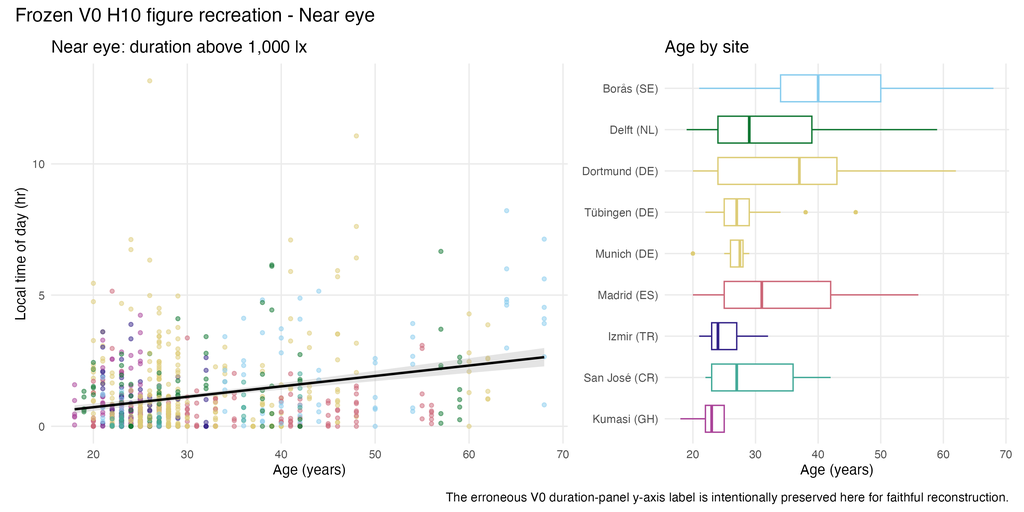

**Near-eye label correction**

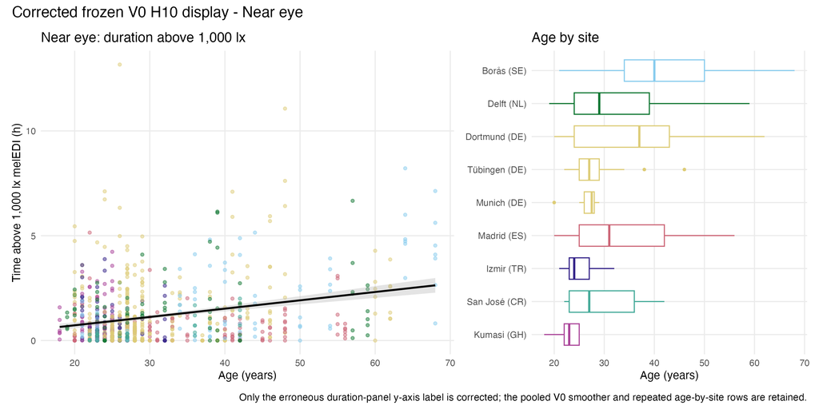

**Chest V0 recreation**

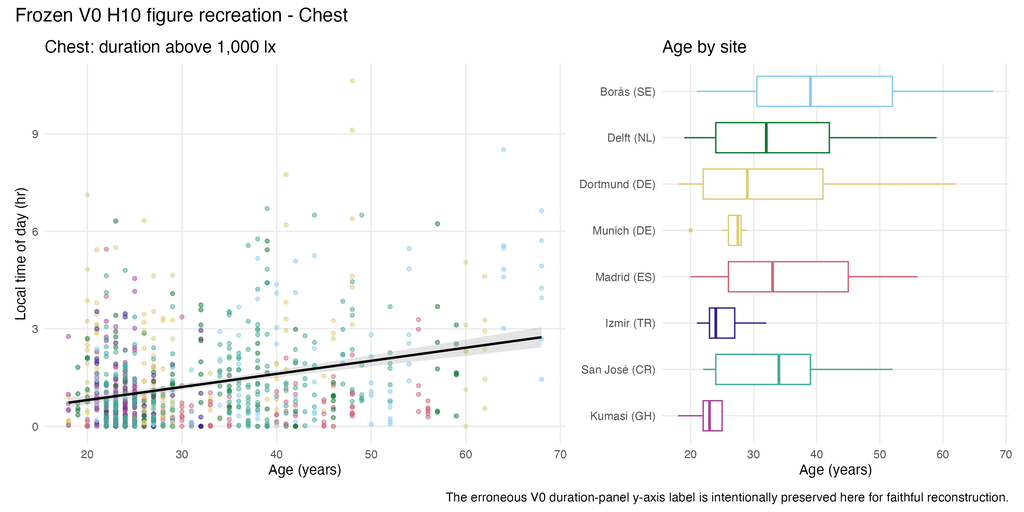

**Chest label correction**

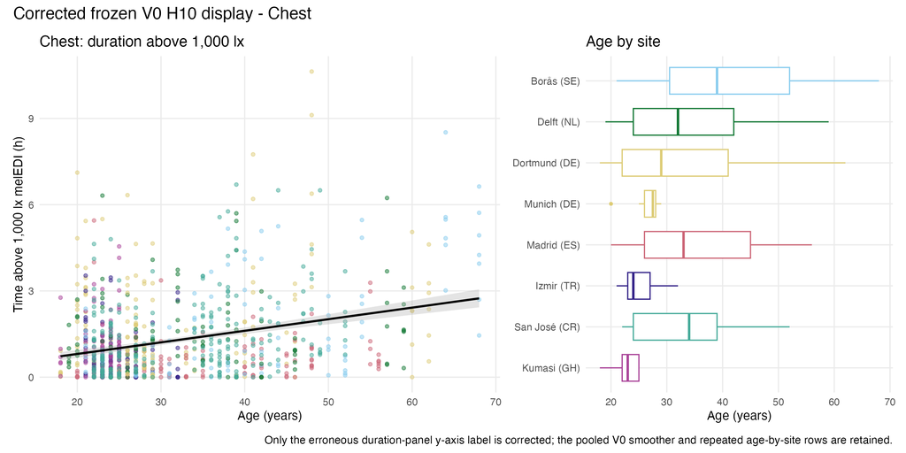

# 10 Reproducibility and artifact map

The implementation is fully hypothesis-scoped:

1. `scripts/hypotheses/H10/h10_contract.R` defines the approved metrics, response packages, formulas, comparisons, pins, and decisions.
2. `scripts/hypotheses/H10/h10_modeling.R` prepares frames, fits models, extracts CIs, and calculates bounded analytical diagnostics.
3. `scripts/hypotheses/H10/run_h10_stage2.R` records the original complete implementation and is used only in manifest mode for the current seal.
4. `scripts/hypotheses/H10/run_h10_metric010_update.R` records the bounded repaired-gap MDER reseal.
5. `scripts/hypotheses/H10/run_h10_metric011_update.R` verifies all 36 current pins, refits only the authorized primary L10 branches, recalculates their complete BH families, and identity-guards every frozen model and raw *p*-value.
6. `scripts/hypotheses/H10/build_h10_metric011_figures.R` rebuilds only displays and paired source CSVs that can contain the L10 slot or affected BH fields, without fitting or prediction.
7. `tests/hypotheses/H10/test_h10_stage2.R` validates formulas, families, samples, response contracts, diagnostics, figure/source pairs, selective-update identities, and checksums.

All durable figures have paired source-data CSVs and PDF exports. The model objects, exact model-frame hashes, model formulas, warnings, errors, log likelihoods, CIs, raw and adjusted p-values, diagnostic thresholds, and execution environment are stored under the H10 artifact directories. Rendering this report reads those artifacts; it does not refit, predict, simulate, bootstrap, or recompute results.

Execution environment

| component | version_or_status |
| --- | --- |
| R | 4.6.1 |
| Quarto | 1.9.37 |
| dplyr | 1.2.1 |
| tidyr | 1.3.2 |
| purrr | 1.2.2 |
| tibble | 3.3.1 |
| readr | 2.2.0 |
| digest | 0.6.39 |
| openssl | 2.4.2 |
| lme4 | 2.0.1 |
| reformulas | 0.4.4 |
| glmmTMB | 1.1.14 |
| performance | 0.17.1 |
| ggplot2 | 4.0.3 |
| patchwork | 1.3.2 |
| sass | 0.4.10 |
| scales | 1.4.0 |
| rvest | 1.0.5 |
| gt | 1.3.0 |
| resampling | None; no bootstrap, simulation, or other resampling was required, so the pilot gate was not triggered |
| METRIC-010 selective update | R 4.6.1; four all-available MDER bundles, accepted MDER sample comparisons, and 36 MDER LOSO rows only; no resampling, so the pilot/runtime gate was not triggered |
| METRIC-010 repaired gap reseal | R 4.6.1; two corrected gap all-available MDER bundles, corrected gap paired/matched branches, and both sides of the revised primary-gap common samples only; primary all-available, primary paired, prim… |
| METRIC-011 selective update | R 4.6.1; two primary all-available L10 bundles, four primary paired main models, four primary-side common-sample main models, 36 L10 LOSO rows, and four participant-deletion models only; every non-L10… |

The project library was used directly because a concurrent task held renv’s startup sandbox lock; no package was installed or updated.

**NoteClosed author record**

H10-G2, the standalone reader report, and the preparation/provenance companion were approved. FIND-049/CHG-101 was bounded to corrected gap MDER and revised common-sample outputs. METRIC-011 was bounded to the eight normalized primary L10 cells and the branches that consumed them. No resampling was required; all frozen identity guards passed, no non-L10 raw *p*-value changed, and every retained scientific conclusion remained unchanged.